# StMo Analysekonzept

Corinna Grobe

2020-07-27

# 1 Business Understanding

Die Kurzzeitprognose des Verkehrsaufkommens ist weithin als ein wichtiges Element intelligenter Verkehrssysteme (ITS) anerkannt, da die Genauigkeit der Prognosemethoden bis zu einem gewissen Grad die Leistung der Echtzeit-Verkehrssteuerung und des Verkehrsmanagements bestimmt. Im Rahmen eines beim Tiefbauamt des Kantons Zürich (TBA) laufenden Projekts sollen die Echtzeit-Daten der Verkehrsmessstellen auf Zürcher Kantonsstrassen als Open Government Data (OGD) zur freien Nutzung zugänglich gemacht werden. Die Analyse verschiedener Prognosemethoden soll ein potentieller Grundstein für mögliche nachfolgende Anwendungen sein.

## 1.1 Ziel

Ziel ist es, diejenige Vorhersagemethode auszuwählen, welche unter Verwendung von historischen Messstellendaten am besten geeignet ist kurzzeitige Prognosen des Verkehrsaufkommens zu leisten.

## 1.2 Fragestellung

Welches ist die am besten geeignete Verkehrsprognose-Methode für kurzzeitige Verkehrsprognosen im Zürcher Kantonsstrassennetz?

## 1.3 Abgrenzungen

1. Vorhersagehorizont: Kurzzeit → Verkehrsaufkommen (flow) mit Zeithorizont 1 Stunde
2. Umfang der Vorhersage: Statisch → Zwei feste Messstellen auf Zürcher Kantonsstrassen
3. Umwelt: Kantonsstrassen → nicht städtisch, aber auch nicht Autobahn
4. Zielvariable: *flow* (Fahrzeuge/Stunde) auch bekannt als *intensity*
5. Prädiktoren: Monat, Wochentag (Mo-So), Stunde vom Tag (24h), Feiertage und Ferien*
- In einem umfassenderen Modell könnten noch Baustellen und meteorologische Faktoren eingeschlossen werden

## 1.4 Schlüsselpersonen & Risiken

### 1.4.1 Schlüsselpersonen

**Dateneigentümerin:** Derzeit sind die Verkehrszähldaten einzig über die Besitzerin der Messtellen, dem Tiefbauamt des Kantons Zürich (TBA), zu beziehen. Die Dateneigentümerin ist somit die erste Schlüsselperson. Sie stellt die technische Infrastruktur, Datenerhebung sowie Datenlieferung bereit.

**Fachexperten:** Aufgrund ihrer Feldexpertise nehmen die Verkehrsdatenerfassung und die Gebietsleitung beim TBA ebenfalls Schlüsselrollen ein. Ihre tiefgreifenden Kenntnisse der Messstationen, der Messstellengebiete sowie der technischen Besonderheiten sind für ein solides Datenverständnis unabdingbar. Hinzukommt das Statistische Amt Kanton Zürich, welches seine Data Science Kompetenz in die Datenaufbereitung und Modellierung einbringt.

### 1.4.2 Organisatorische Risiken

Es handelt sich um ein amtsübergreifendes Projekt zwischen dem Tiefbauamt und dem Statistischen Amt Kanton Zürich. Eine kollaborative Zusammenarbeit und kontinuierlicher Austausch sind zwingend nötig.

### 1.4.3 Technische Risiken

**Messung:** Das grösste technische Risiko liegt in der Datenerhebung. Nur möglichst kontinuierlich erfasste Verkehrszähldaten erlauben eine gute Prognose. Technische Unterbrüche, Baustellen oder andere Störungen beeinträchtigen die Datenqualität und damit die Prognosegenauigkeit.

**Skalierbarkeit:** Bei einer Anwendung der Methode auf Echtzeit-Daten wächst die Datenmenge rasch an und erfordert ein Datenmanagement und eine Datenverarbeitung mit Big Data-Verfahren sowie entsprechende Speicher- und Rechenkapazitäten.

## 1.5 Erfolgskriterien

**Accuracy:** In der Regel wird die Genauigkeit einer Vorhersage durch eine Statistik gemessen. (1) **AIC** Im Modellvergleich dient der AIC als Kriterium für den Goodness-of-fit. (2) **MAPE** Der MAPE dient zur Beurteilung der Genauigkeit der Vorhersage, ausgedrückt als mittlerer absoluter prozentualer Fehler aus.

**Rechnerischer Aufwand:** Die verwendete Methode soll einen überschaubaren (geringen) rechnerischen Aufwand erfordern und eine einfache Implementation erlauben.

## 1.6 Zielgruppe

Die Echtzeit-Daten der Verkehrsmessstellen im Kanton Zürich sollen unter dem OGD Datenstandard frei verfügbar gemacht werden. Die Beurteilung möglicher Prognosemodelle für diese Verkehrszähldaten soll primär **(1) der interessierten OGD-Community** als Grundlage für die Erstellung möglicher Applikationen dienen. Darüber hinaus kann die Arbeit auch **(2) in der Planung von Echtzeit-Verkehrssteuerungssystemen und dem Verkehrsmanagement** dienen.

# 2 Data Understanding

**Datenverfügbarkeit:** Insgesamt stehen die Verkehrszähldaten von 15 MIV-Messtellen im Grossraum Zürichsee für den Zeitraum 1.1.-30.6.2020 sowie der Vorjahresperiode zur Verfügung. Gemessen wird das Total an Fahrzeugen in 15-Minuten-Intervallen. In jedem Zeitintervall werden die gezählten Fahrzeuge zusätzlich nach zehn Fahrzeugkategorien unterschieden. Ausserdem liegen Angaben zur Fahrtrichtung sowie bei mehrspurigen Strassen zur Spur vor. Keine Angaben liegen vor zur Geschwindigkeit.

Informationen zu den Prädiktoren, Wochentag, Stunde vom Tag, Feiertag / Ferien sowie Baustellen oder andere Unterbrüche, werden entweder mit den Verkehrszähldaten geliefert oder lassen sich anhand dieser ergänzen.

Somit ist ein ausreichende Datengrundlage gegeben, um verschiedene Modell zu erstellen und zu testen.

**Quantitative und qualitative Aspekte:**

- Genügend grosser Pool an Messstationen, um für die Modellanpassungen solche ohne Messunterbrüche auswählen zu können.
- Der Trainingsdatensatz (jan-Jun. 2019) umfasst lediglich die ersten sechs Monate des Jahres. Es liegt somit kein Jahresrhythmus vor und der prospektive Einsatz des Modells ist somit limitiert.
- Beim Test-Datensatz (Jan.-Jun. 2020) kommen ab Mitte März, also mit Beginn der ausserordentlichen Lage aufgrund der Corona-Pandemie, stark abweichende Messungen auf. Das Testen des Modells bietet sich somit nur für die Monate Januar und Februar 2020 an.
- Feier- und Ferientage sind selbst innerkantonal nicht immer deckungsgleich. Ja nach Standort der Messstation gelten also ggf. andere Feiertage. Es ist kein OGD-Datensatz solcher Daten bekannt, so dass Feier- und Ferientage manuell ergänzt und angepasst werden müssen.

## 2.1 Rechtliches & Finanzielles

Es handelt sich um frei verfügbare, nicht personenbezogen Daten. Aspekte des Datenschutzes sind somit nicht relevant, ebensowenig müssen keine kostenpflichtigen Daten hinzugekauft werden.

# 3 Data Preparation

**Missing Values** Fehlende Werte können verschiedene Ursachen haben: Baustellen, technische Störungen und Unterbrüche.

Es wird keine Imputation der fehlenden Werte vorgenommen. 1) Fehlende Werte können immer wieder vorkommen und sollten darum Teil des Modells sein. 2) Mit Imputation wird das Modell ggf. eher schlechter, da es nicht mehr modelliert, was die aktuelle Situation ist.

**Ausreisser** Besonders tiefe oder hohe Werte, die nur einmalig oder kurzzeitig vorkommen, lassen sich im Idealfall aufgrund von Baustellen oder technischen Störungen erklären. Solche erklärbaren Ausreisser werden wie Missing Values behandelt.

**Saisonalität** Saisonalität entsteht zum einen, als dass es jährlich wiederkehrende Ereignisse wie Feiertage und Ferien gibt. Zum anderen durch die Wochentage: Wochenenden weichen erkennbar vom Muster der Arbeitstage ab. Diese Formen der saisonalen Muster müssen im Modell berücksichtigt werden.

## 3.1 Variablen: Standardisierung, Transformation, Aggregation und Selektion

**Messstation:** Name und Nummer der Messstation.

**Datum:** Das Datum wird als `as.POSIXct` im Format `"%Y-%m-%d %H:%M:%S"` gespeichert.

**Monat**: Der Monat als eigene Variable, um den Einfluss von einer Saisonalität, z.B. durch Ferien, nachverfolgen zu können.

**Wochentag:** Der Wochentag wird dem Datensatz als neue Variable hinzugefügt und aus dem Datum extrahiert: Konvertierung von Datum in `as.Date`. Dabei ist Montag als erster Tag der Woche definiert.

**Stunde:** Stunde vom Tag.

**Total Fahrzeuge:** Die Messswerte sind in der Variable `flow`als Stundensumme angegeben. Eine Unterschiedung in Fahrzeugkategorien ist nicht notwendig und der Datensatz wird um die 10 Variablen zur Fahrzeugkategorie reduziert. Bei mehrspurigen Strassen werden die Spuren, die in die gleiche Richtung führen, kumuliert.

| date | weekday | weekday_num | month | flow_daysum | sqrt_flow | holiday | schoolholiday |
| --- | --- | --- | --- | --- | --- | --- | --- |
| 2019-01-01 | Dienstag | 2 | 1 | 6491 | 80 | 1 | 1 |
| 2019-01-02 | Mittwoch | 3 | 1 | 7154 | 84 | 1 | 1 |
| 2019-01-03 | Donnerstag | 4 | 1 | 9648 | 98 | 0 | 1 |
| 2019-01-04 | Freitag | 5 | 1 | 10653 | 103 | 0 | 1 |
| 2019-01-05 | Samstag | 6 | 1 | 9188 | 95 | 0 | 1 |
| 2019-01-06 | Sonntag | 7 | 1 | 7632 | 87 | 0 | 0 |

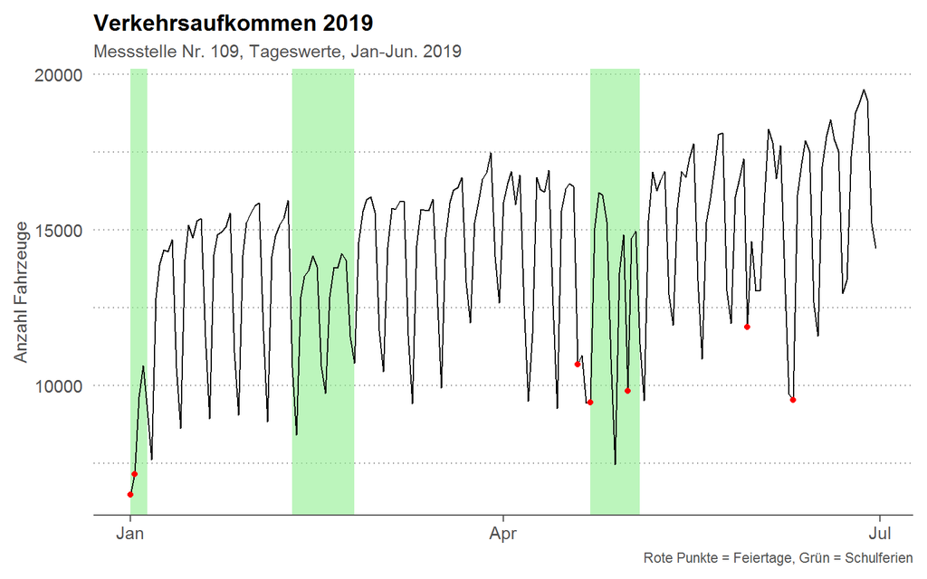

# 4 Modelling

**Modellselektion**

Lineare Regression: Modellierung basiert auf den Beobachtungen und einem Fehlerterm. Das Modellieren mit Zeitreihen bedingt, dass der Prozess stationär ist, d.h. Saisonalität muss mit modelliert werden.

```
##
## Family: gaussian
## Link function: identity
##
## Formula:
## flow_daysum ~ s(month, bs = "cc", k = 6) + weekday + holiday +
##     schoolholiday
##
## Estimated degrees of freedom:
## 1.63  total = 10.63
##
## REML score: 1496.047
```

## 4.1 Analytische Verfahren anwenden

–> siehe “StMo Analysekonzept - Modellanpassung”

# 5 Evaluation

Schwächen zeigt das Modell in Wochen mit einem “unerwartet” hohem resp. tiefen Verkehrsaufkommen. Für diese Fälle muss dem Modell ein Korrekturfaktor hinzugefügt werden. Dieser könnte bspw. aus den Residuen geschätzt werden. Wird das Modell in einem Pool von Messstellen angewendet, könnte der Faktorterm für die vergangene Periode über verschiedene Messstellen gepoolt werden. **Das Pooling von vergleichbaren Messstellen im Modell könnte eine erste Weiterentwicklung des Modells sein.**

**Geeingnetheit des Modells zur Beantwortung der Fragestellung:** Das Modell zeigt die lokalen Effekte an einer stationären Stelle und für eine Stunde/Tag im Messstellennetz. Um aber Aussagen über Stationen in der Peripherie oder gar das ganze Netz treffen zu können, benötigt es zum einen Echtzeitdaten. Erst so können auch Aussagen über den `flow` an vor- und nachgelagerten Messstellen getroffen werden. Mit Stunden- oder Tageswerten lassen sich auf Basis einer Station keine Prognosen zum Verkehrsaufkommen an anderen Stationen machen. **Die Anpassung des Modells mit Echtzeitdaten und für die Peripherie der Messstationen könnte eine zweite Weiterentwicklung des Modells sein.**

# 6 Deployment

Im Betrieb wird es primär um die Pflege des Modells gehen. Das Modell mit den aktualisierten Daten regelmässig evaluiert, angepasst und neu gerechnet. Hierfür ist ein geeigneter Rhythmus zu definieren.

Damit das Modell z.B. in intelligenten Verkehrssystemen (ITS) eingesetzt werden kann, muss es adaptiv gestaltet sein. Das heisst, es müssen Schnittstellen für die aktuellen Daten geschaffen werden, diese müssen Prozessiert und die Vorhersagen an das ITS zurückgespielt werden. Ein solches Setup ist besonders bei Echtzeitdaten relevant.